# Effects of Loan Characteristics on Loan Amount and Interest Rate

## Investigation Overview

> In this investigation, I wanted to look at the characteristics of loan that could possibly impact the loan amount and intereat rate.

## Dataset Overview

> Prosper is a peer-to-peer lending platform and this dataset contains loan data across time. Check out the full description [here](https://www.google.com/url?q=https://docs.google.com/spreadsheet/ccc?key%3D0AllIqIyvWZdadDd5NTlqZ1pBMHlsUjdrOTZHaVBuSlE%26usp%3Dsharing&sa=D&ust=1554486256024000).

```python
# import all packages and set plots to be embedded inline
import numpy as np
import pandas as pd
import matplotlib.pyplot as plt
import seaborn as sns

%matplotlib inline

# suppress warnings from final output
import warnings
warnings.simplefilter("ignore")
```

```python
#Optimize pandas display options for viewing and analyzing the data
pd.set_option('display.max_columns', None)
pd.set_option('display.max_rows', None)
pd.set_option('display.max_colwidth', -1)
```

```python
#Load dataset
df=pd.read_csv('prosperLoanData.csv')
```

```python
#Select my features of interest and create a sub dataset
cols=['ListingNumber','LoanStatus','BorrowerAPR','ProsperScore',
      'EmploymentStatus','EmploymentStatusDuration','TradesNeverDelinquent (percentage)','DebtToIncomeRatio',
     'IncomeRange','LoanOriginalAmount']
prosper=df[cols].dropna()
#Change all column names to lowercase, and shorten long column names
prosper.rename(columns={'ListingNumber':'id','LoanStatus':'Status','ProsperScore':'prosper_score',
                        'EmploymentStatus':'employment','EmploymentStatusDuration':'job_duration',
                        'TradesNeverDelinquent (percentage)':'non-delinquency','DebtToIncomeRatio':'debt/income',
                        'IncomeRange':'income_range','LoanOriginalAmount':'ori_Amount'},inplace=True)
prosper.columns=[x.lower() for x in prosper.columns]
prosper.info()
```

```
<class 'pandas.core.frame.DataFrame'>
Int64Index: 77543 entries, 1 to 113936
Data columns (total 10 columns):
id                 77543 non-null int64
status             77543 non-null object
borrowerapr        77543 non-null float64
prosper_score      77543 non-null float64
employment         77543 non-null object
job_duration       77543 non-null float64
non-delinquency    77543 non-null float64
debt/income        77543 non-null float64
income_range       77543 non-null object
ori_amount         77543 non-null int64
dtypes: float64(5), int64(2), object(3)
memory usage: 6.5+ MB
```

```python
prosper=prosper[prosper.prosper_score!=11]
prosper=prosper.query('income_range!="not employed"')
income_class=['$1-24,999','$25,000-49,999','$50,000-74,999','$75,000-99,999','$100,000+']
income_class_var=pd.CategoricalDtype(ordered = True,categories=income_class)
prosper.income_range=prosper.income_range.astype(income_class_var)
prosper['non-delinquency']= prosper['non-delinquency']*100
```

## Distribution of Loan Status

> Almost 70% of the loans are current, and over 20% are complete. Less than 10% are charged off, defaulted or past due.

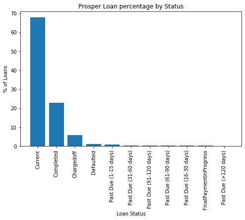

```python
#Caculate the percentage of loans per outcome
loan_status=(prosper.status.value_counts()/len(prosper))*100
plt.figure(figsize=[8, 5])
plt.bar(x=loan_status.index,height=loan_status)
plt.xticks(rotation=90)
plt.xlabel('Loan Status')
plt.ylabel('% of Loans')
plt.title('Prosper Loan percentage by Status')
plt.show();
```

## The Distribution of Borrower APR

> The distribution of annual interest rate that borrowers incur looks roughly bimodal. There are a peak around 20% and the second peak around 35%. The majority of the rates fall in the range of 12.5% to 37%.

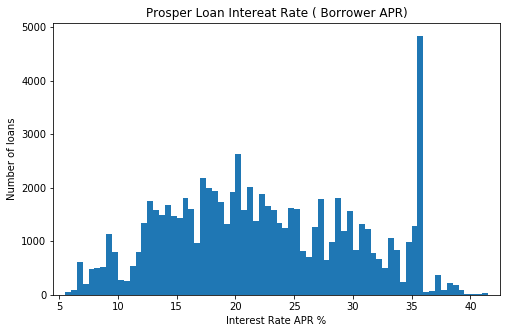

```python
prosper.borrowerapr=prosper.borrowerapr*100
prosper.borrowerapr.describe()
plt.figure(figsize=[8, 5])
bin_edges=np.arange(4.5,42.5,0.5)
plt.hist(prosper.borrowerapr,bin_edges)
plt.xlabel('Interest Rate APR %')
plt.ylabel('Number of loans')
plt.ylabel
plt.xlim([4.5,42.5])
plt.title('Prosper Loan Intereat Rate ( Borrower APR)')
plt.show();
```

## The Distribution of Original Loan Amount

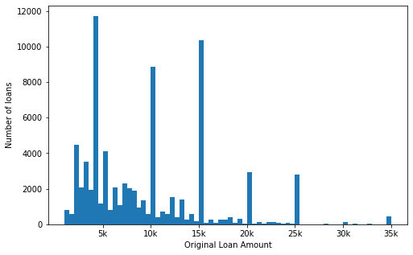

```python
#Plot the original loan amount
plt.figure(figsize=[8, 5])
bin_edges=np.arange(prosper.ori_amount.min(),prosper.ori_amount.max()+500,500)
plt.hist(prosper.ori_amount,bins=bin_edges)
plt.xticks([5000,10000,15000,20000,25000,30000,35000],['5k','10k','15k','20k','25k','30k','35k'])
plt.ylabel('Number of loans')
plt.xlabel('Original Loan Amount')
plt.show();
```

## The relationships between APR, loan amount and categorical variables

> 1. Interest rate has a negative relationship with Prosper score and income. It makes sense intuitively, as borrowing rate is lower for high-ranking loans (low risk) and individuals from high-income brackets. In general, interest rates are also higher for past-due, defaulted and charged off loans.
> 2. Original loan amount has a positive relationship withh Prosper score and income. Interestingly, loans that are charged-off or defaulted tend to be small. This is worthy of further investigation with more data points.

```python
#Seperate the numerical variables from categorical variable
numeric_vars=['borrowerapr','job_duration','non-delinquency','debt/income','ori_amount']
#Treat prosper_score as ordinal categorical variable
categoric_vars=['status','prosper_score','income_range']
stat=['Completed','FinalPaymentInProgress','Current','Past Due (1-15 days)','Past Due (16-30 days)','Past Due (31-60 days)',
     'Past Due (61-90 days)','Past Due (91-120 days)','Past Due (>120 days)','Defaulted','Chargedoff']
stat_cat=pd.CategoricalDtype(ordered=True,categories=stat)
prosper.status=prosper.status.astype(stat_cat);
```

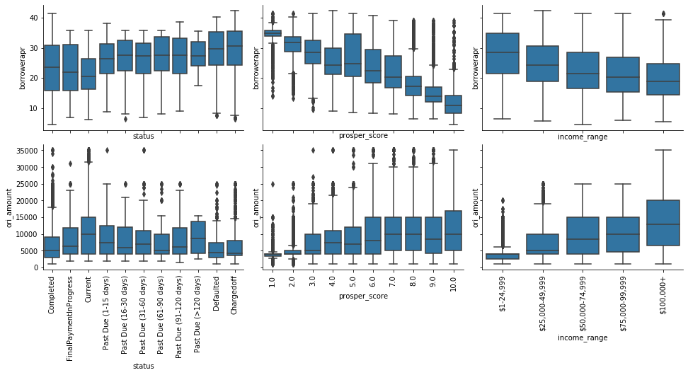

```python
# plot matrix of numeric features against categorical features.
def boxgrid(x, y, **kwargs):
    base_color = sns.color_palette()[0]
    sns.boxplot(x, y, color = base_color)

plt.figure(figsize = [8, 8])
g = sns.PairGrid(data = prosper, y_vars = ['borrowerapr','ori_amount'], x_vars = categoric_vars,
                height = 3, aspect = 1.5)
g.map(boxgrid)

# Show labels for each subplot
xlabels,ylabels = [],[]
for ax in g.axes[-1,:]:
    xlabel = ax.xaxis.get_label_text()
    xlabels.append(xlabel)
for ax in g.axes[:,0]:
    ylabel = ax.yaxis.get_label_text()
    ylabels.append(ylabel)

for i in range(len(xlabels)):
    for j in range(len(ylabels)):
        g.axes[j,i].xaxis.set_label_text(xlabels[i])
        g.axes[j,i].yaxis.set_label_text(ylabels[j])

#Rotate the text so that they are legible
for ax in g.axes.flat:
    plt.setp(ax.get_xticklabels(), visible=True)
    for label in ax.get_xticklabels():
        label.set_rotation(90)

plt.show();
```

## How loan status plays into the relationship between original loan amount and borrower APR?

> Compared to the current loans, charged-off and defaulted loan are normally small and high interest bearing. Completed loans also tend to be small.

```python
def hist2dgrid(x, y, **kwargs):
    palette = kwargs.pop('color')
    bins_x = np.arange(4.5,42.5,1)
    bins_y = np.arange(prosper.ori_amount.min(),prosper.ori_amount.max(),1000)
    plt.hist2d(x, y, bins = [bins_x, bins_y], cmap = palette, cmin = 0.5)
    plt.yticks([5000,10000,15000,20000,25000,30000,35000],['5k','10k','15k','20k','25k','30k','35k'])
```

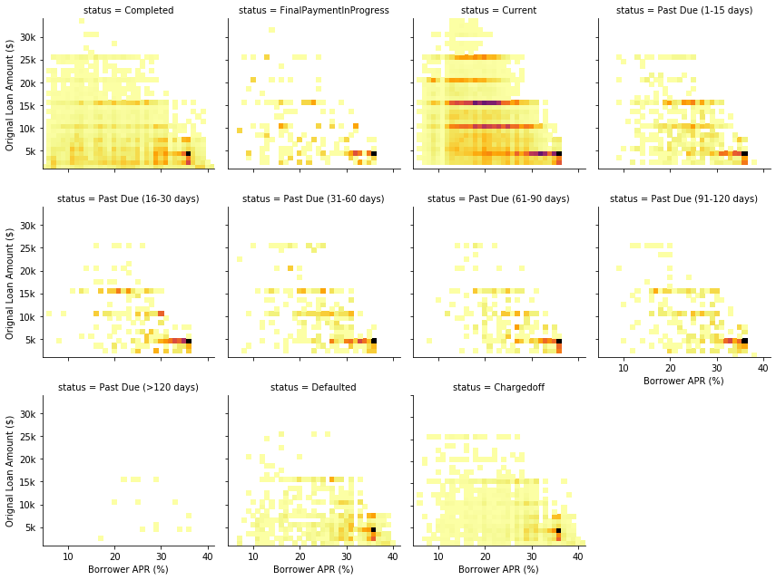

```python
# create faceted heat maps on each loan status
plt.figure(figsize=[10,8])
g = sns.FacetGrid(data = prosper, col = 'status', col_wrap = 4, height = 3,
                 xlim = [4.5,42.5])
g.map(hist2dgrid,'borrowerapr', 'ori_amount', color = 'inferno_r')
g.set_xlabels('Borrower APR (%)')
g.set_ylabels('Orignal Loan Amount ($)')

plt.show();
```

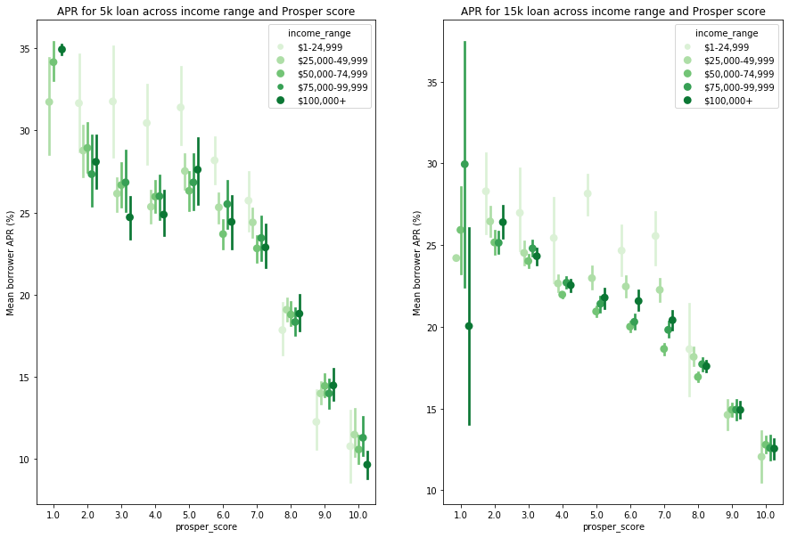

```python
#Select the subsets
prosper_5k=prosper.query('ori_amount==5000')
prosper_15k=prosper.query('ori_amount==15000')
fig, ax = plt.subplots(ncols = 2, figsize = [15,10])

#Subplot 1: 5k loan
sns.pointplot(data=prosper_5k, x='prosper_score',y='borrowerapr',hue='income_range',palette='Greens',
             linstyles='',dodge=0.5,ax=ax[0],join=False)
ax[0].set_title('APR for 5k loan across income range and Prosper score')
ax[0].set_ylabel('Mean borrower APR (%)')

#Subplot 2: 15k loan
sns.pointplot(data=prosper_15k,x='prosper_score',y='borrowerapr',hue='income_range',palette='Greens',
              linstyles='',dodge=0.5,ax=ax[1],join=False)
ax[1].set_title('APR for 15k loan across income range and Prosper score')
ax[1].set_ylabel('Mean borrower APR (%)')

plt.show();
```

## There are a lot of loans with APR around 35% and around 20%. What are the expected loan amounts given the levels of income range and propser score?

> The mean loan amount differentials across income range at a given prosper score play differently for 20% and 35% APR loans. Perhaps loans with 35% APR are deemed very risky and the impacts of income range and prosper score on loan amounts are therefore muted.

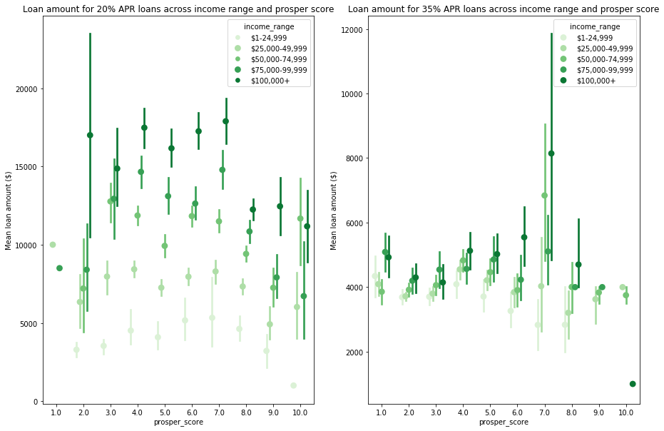

```python
#Select the subsets
prosper_20pct=prosper.query('(borrowerapr>=19.5) & (borrowerapr<=20.5)')
prosper_35pct=prosper.query('(borrowerapr>=34.5) & (borrowerapr<=35.5)')
fig,ax=plt.subplots(ncols=2,figsize=[15,10])

#Subplot 1: 20% loans
sns.pointplot(data=prosper_20pct,x='prosper_score',y= 'ori_amount', hue='income_range',palette='Greens',
             ax=ax[0],join=False,dodge=0.5)
ax[0].set_title('Loan amount for 20% APR loans across income range and prosper score')
ax[0].set_ylabel('Mean loan amount ($)')

#Subplot 2: 35% loans
sns.pointplot(data=prosper_35pct,x='prosper_score',y='ori_amount',hue='income_range',palette='Greens',
             ax=ax[1],join=False,dodge=0.5)
ax[1].set_title('Loan amount for 35% APR loans across income range and prosper score')
ax[1].set_ylabel('Mean loan amount ($)')

plt.show();
```